# Data Exploration

## Nba data analysis

Analyze the nba dataset following the steps below.

### Load the main packages

The main package `tidyverse` contains the `ggplot` and `dplyr` libraries which have our main functions.

```r
library(tidyverse)
```

### Load data

```r
ranking = read.csv("/Users/georgegasparis/GitHub/GraphBasketAnalysis/Data/ranking.csv")
teams = read.csv("/Users/georgegasparis/GitHub/GraphBasketAnalysis/Data/teams.csv")
player = read.csv("/Users/georgegasparis/GitHub/GraphBasketAnalysis/Data/players.csv")
games = read.csv("/Users/georgegasparis/GitHub/GraphBasketAnalysis/Data/games.csv")
games_details = read.csv("/Users/georgegasparis/GitHub/GraphBasketAnalysis/Data/games_details.csv")
```

### Overview

A quick dataset overview on the first 10 rows. The function `head` allows us to see the first 6 rows by default.

```r
head(games_details, 10)
```

|  | GAME_ID | TEAM_ID | TEAM_ABBREVIATION | TEAM_CITY | PLAYER_ID | PLAYER_NAME | START_POSITION | COMMENT | MIN | FGM | FGA | FG_PCT | FG3M | FG3A | FG3_PCT | FTM | FTA | FT_PCT | OREB | DREB | REB | AST | STL | BLK | TO | PF | PTS | PLUS_MINUS |
| --- | --- | --- | --- | --- | --- | --- | --- | --- | --- | --- | --- | --- | --- | --- | --- | --- | --- | --- | --- | --- | --- | --- | --- | --- | --- | --- | --- | --- |
| 1 | 21900895 | 1610612749 | MIL | Milwaukee | 202083 | Wesley Matthews | F |  | 27:08 | 3 | 11 | 0.273 | 2 | 7 | 0.286 | 0 | 0 | 0.000 | 4 | 4 | 8 | 2 | 2 | 0 | 0 | 0 | 8 | 11 |
| 2 | 21900895 | 1610612749 | MIL | Milwaukee | 203507 | Giannis Antetokounmpo | F |  | 34:55 | 17 | 28 | 0.607 | 1 | 4 | 0.250 | 6 | 7 | 0.857 | 2 | 18 | 20 | 6 | 1 | 0 | 3 | 2 | 41 | 22 |
| 3 | 21900895 | 1610612749 | MIL | Milwaukee | 201572 | Brook Lopez | C |  | 26:25 | 4 | 11 | 0.364 | 1 | 5 | 0.200 | 7 | 9 | 0.778 | 2 | 5 | 7 | 0 | 0 | 3 | 0 | 2 | 16 | 16 |
| 4 | 21900895 | 1610612749 | MIL | Milwaukee | 1628978 | Donte DiVincenzo | G |  | 27:35 | 1 | 5 | 0.200 | 0 | 3 | 0.000 | 0 | 0 | 0.000 | 1 | 6 | 7 | 5 | 0 | 1 | 2 | 0 | 2 | 14 |
| 5 | 21900895 | 1610612749 | MIL | Milwaukee | 202339 | Eric Bledsoe | G |  | 22:17 | 2 | 8 | 0.250 | 0 | 1 | 0.000 | 0 | 0 | 0.000 | 1 | 0 | 1 | 2 | 1 | 0 | 3 | 2 | 4 | 6 |
| 6 | 21900895 | 1610612749 | MIL | Milwaukee | 1626192 | Pat Connaughton |  |  | 24:52 | 2 | 5 | 0.400 | 1 | 4 | 0.250 | 1 | 2 | 0.500 | 2 | 3 | 5 | 1 | 0 | 0 | 1 | 2 | 6 | 0 |
| 7 | 21900895 | 1610612749 | MIL | Milwaukee | 201577 | Robin Lopez |  |  | 13:18 | 1 | 5 | 0.200 | 0 | 0 | 0.000 | 0 | 0 | 0.000 | 1 | 2 | 3 | 0 | 0 | 1 | 2 | 1 | 2 | -12 |
| 8 | 21900895 | 1610612749 | MIL | Milwaukee | 1628425 | Sterling Brown |  |  | 18:10 | 1 | 2 | 0.500 | 1 | 2 | 0.500 | 0 | 0 | 0.000 | 0 | 3 | 3 | 0 | 0 | 0 | 1 | 0 | 3 | -8 |
| 9 | 21900895 | 1610612749 | MIL | Milwaukee | 101107 | Marvin Williams |  |  | 19:37 | 0 | 1 | 0.000 | 0 | 1 | 0.000 | 0 | 0 | 0.000 | 0 | 2 | 2 | 2 | 1 | 1 | 1 | 1 | 0 | -11 |
| 10 | 21900895 | 1610612749 | MIL | Milwaukee | 201588 | George Hill |  |  | 25:43 | 4 | 11 | 0.364 | 1 | 4 | 0.250 | 2 | 3 | 0.667 | 2 | 3 | 5 | 2 | 2 | 0 | 3 | 1 | 11 | 2 |

### Dimensions

The functions `dim` displays the dimension of the table and function `glimpse`, from `dplyr` package, displays a vertical preview of the dataset.

```r
dim(games_details)
```

```
[1] 576782     28
```

```r
glimpse(games_details)
```

```
Rows: 576,782
Columns: 28
$ GAME_ID           <int> 21900895, 21900895, 21900895, 21900895, 21900895, 21900895, 21…
$ TEAM_ID           <int> 1610612749, 1610612749, 1610612749, 1610612749, 1610612749, 16…
$ TEAM_ABBREVIATION <chr> "MIL", "MIL", "MIL", "MIL", "MIL", "MIL", "MIL", "MIL", "MIL",…
$ TEAM_CITY         <chr> "Milwaukee", "Milwaukee", "Milwaukee", "Milwaukee", "Milwaukee…
$ PLAYER_ID         <int> 202083, 203507, 201572, 1628978, 202339, 1626192, 201577, 1628…
$ PLAYER_NAME       <chr> "Wesley Matthews", "Giannis Antetokounmpo", "Brook Lopez", "Do…
$ START_POSITION    <chr> "F", "F", "C", "G", "G", "", "", "", "", "", "", "", "", "F", …
$ COMMENT           <chr> "", "", "", "", "", "", "", "", "", "", "DNP - Coach's Decisio…
$ MIN               <chr> "27:08", "34:55", "26:25", "27:35", "22:17", "24:52", "13:18",…
$ FGM               <dbl> 3, 17, 4, 1, 2, 2, 1, 1, 0, 4, NA, NA, NA, 3, 5, 2, 7, 6, 4, 1…
$ FGA               <dbl> 11, 28, 11, 5, 8, 5, 5, 2, 1, 11, NA, NA, NA, 13, 14, 8, 18, 1…
$ FG_PCT            <dbl> 0.273, 0.607, 0.364, 0.200, 0.250, 0.400, 0.200, 0.500, 0.000,…
$ FG3M              <dbl> 2, 1, 1, 0, 0, 1, 0, 1, 0, 1, NA, NA, NA, 1, 1, 0, 3, 0, 2, 0,…
$ FG3A              <dbl> 7, 4, 5, 3, 1, 4, 0, 2, 1, 4, NA, NA, NA, 7, 8, 0, 8, 3, 5, 1,…
$ FG3_PCT           <dbl> 0.286, 0.250, 0.200, 0.000, 0.000, 0.250, 0.000, 0.500, 0.000,…
$ FTM               <dbl> 0, 6, 7, 0, 0, 1, 0, 0, 0, 2, NA, NA, NA, 0, 1, 4, 0, 1, 1, 0,…
$ FTA               <dbl> 0, 7, 9, 0, 0, 2, 0, 0, 0, 3, NA, NA, NA, 0, 1, 4, 1, 1, 1, 0,…
$ FT_PCT            <dbl> 0.000, 0.857, 0.778, 0.000, 0.000, 0.500, 0.000, 0.000, 0.000,…
$ OREB              <dbl> 4, 2, 2, 1, 1, 2, 1, 0, 0, 2, NA, NA, NA, 1, 1, 4, 0, 2, 0, 0,…
$ DREB              <dbl> 4, 18, 5, 6, 0, 3, 2, 3, 2, 3, NA, NA, NA, 3, 5, 5, 2, 1, 5, 1…
$ REB               <dbl> 8, 20, 7, 7, 1, 5, 3, 3, 2, 5, NA, NA, NA, 4, 6, 9, 2, 3, 5, 1…
$ AST               <dbl> 2, 6, 0, 5, 2, 1, 0, 0, 2, 2, NA, NA, NA, 2, 3, 2, 3, 4, 2, 1,…
$ STL               <dbl> 2, 1, 0, 0, 1, 0, 0, 0, 1, 2, NA, NA, NA, 2, 0, 0, 1, 1, 0, 0,…
$ BLK               <dbl> 0, 0, 3, 1, 0, 0, 1, 0, 1, 0, NA, NA, NA, 2, 2, 2, 0, 0, 1, 1,…
$ TO                <dbl> 0, 3, 0, 2, 3, 1, 2, 1, 1, 3, NA, NA, NA, 2, 2, 1, 0, 2, 1, 0,…
$ PF                <dbl> 0, 2, 2, 0, 2, 2, 1, 0, 1, 1, NA, NA, NA, 2, 3, 3, 2, 2, 2, 1,…
$ PTS               <dbl> 8, 41, 16, 2, 4, 6, 2, 3, 0, 11, NA, NA, NA, 7, 12, 8, 17, 13,…
$ PLUS_MINUS        <dbl> 11, 22, 16, 14, 6, 0, -12, -8, -11, 2, NA, NA, NA, -4, -13, -1…
```

### Data summary

`Summary` function shows each column, data type and other attributes. It’s useful as we’re dealing with a numeric dataset. For all the attributes it displays min, 1st quartile, median, mean, 3rd quartile and max values.

```r
summary(games_details)
```

```
    GAME_ID            TEAM_ID          TEAM_ABBREVIATION   TEAM_CITY
 Min.   :10300001   Min.   :1.611e+09   Length:576782      Length:576782
 1st Qu.:20600629   1st Qu.:1.611e+09   Class :character   Class :character
 Median :21100461   Median :1.611e+09   Mode  :character   Mode  :character
 Mean   :21535815   Mean   :1.611e+09
 3rd Qu.:21600196   3rd Qu.:1.611e+09
 Max.   :41800406   Max.   :1.611e+09

   PLAYER_ID         PLAYER_NAME        START_POSITION       COMMENT
 Min.   :1.500e+01   Length:576782      Length:576782      Length:576782
 1st Qu.:2.366e+03   Class :character   Class :character   Class :character
 Median :2.008e+05   Mode  :character   Mode  :character   Mode  :character
 Mean   :2.794e+05
 3rd Qu.:2.027e+05
 Max.   :1.963e+09

     MIN                 FGM             FGA            FG_PCT           FG3M
 Length:576782      Min.   : 0.00   Min.   : 0.00   Min.   :0.00    Min.   : 0.00
 Class :character   1st Qu.: 1.00   1st Qu.: 3.00   1st Qu.:0.25    1st Qu.: 0.00
 Mode  :character   Median : 3.00   Median : 7.00   Median :0.43    Median : 0.00
                    Mean   : 3.56   Mean   : 7.86   Mean   :0.42    Mean   : 0.72
                    3rd Qu.: 5.00   3rd Qu.:11.00   3rd Qu.:0.56    3rd Qu.: 1.00
                    Max.   :28.00   Max.   :50.00   Max.   :1.00    Max.   :14.00
                    NA's   :92261   NA's   :92261   NA's   :92261   NA's   :92261
      FG3A          FG3_PCT           FTM             FTA            FT_PCT
 Min.   : 0.00   Min.   :0.00    Min.   : 0.00   Min.   : 0.00   Min.   :0.00
 1st Qu.: 0.00   1st Qu.:0.00    1st Qu.: 0.00   1st Qu.: 0.00   1st Qu.:0.00
 Median : 1.00   Median :0.00    Median : 1.00   Median : 2.00   Median :0.50
 Mean   : 2.02   Mean   :0.19    Mean   : 1.75   Mean   : 2.32   Mean   :0.44
 3rd Qu.: 3.00   3rd Qu.:0.33    3rd Qu.: 3.00   3rd Qu.: 4.00   3rd Qu.:0.91
 Max.   :24.00   Max.   :1.00    Max.   :26.00   Max.   :39.00   Max.   :1.00
 NA's   :92261   NA's   :92261   NA's   :92261   NA's   :92261   NA's   :92261
      OREB            DREB            REB             AST             STL
 Min.   : 0.00   Min.   : 0.00   Min.   : 0.00   Min.   : 0.00   Min.   : 0.00
 1st Qu.: 0.00   1st Qu.: 1.00   1st Qu.: 1.00   1st Qu.: 0.00   1st Qu.: 0.00
 Median : 1.00   Median : 2.00   Median : 3.00   Median : 1.00   Median : 0.00
 Mean   : 1.04   Mean   : 3.01   Mean   : 4.05   Mean   : 2.08   Mean   : 0.72
 3rd Qu.: 2.00   3rd Qu.: 4.00   3rd Qu.: 6.00   3rd Qu.: 3.00   3rd Qu.: 1.00
 Max.   :18.00   Max.   :25.00   Max.   :31.00   Max.   :25.00   Max.   :10.00
 NA's   :92261   NA's   :92261   NA's   :92261   NA's   :92261   NA's   :92261
      BLK              TO              PF             PTS          PLUS_MINUS
 Min.   : 0.00   Min.   : 0.00   Min.   : 0.00   Min.   : 0.0    Min.   :-57
 1st Qu.: 0.00   1st Qu.: 0.00   1st Qu.: 1.00   1st Qu.: 3.0    1st Qu.: -7
 Median : 0.00   Median : 1.00   Median : 2.00   Median : 8.0    Median :  0
 Mean   : 0.46   Mean   : 1.33   Mean   : 2.02   Mean   : 9.6    Mean   :  0
 3rd Qu.: 1.00   3rd Qu.: 2.00   3rd Qu.: 3.00   3rd Qu.:14.0    3rd Qu.:  6
 Max.   :12.00   Max.   :12.00   Max.   :15.00   Max.   :81.0    Max.   : 57
 NA's   :92261   NA's   :92261   NA's   :92261   NA's   :92261   NA's   :115922
```

`Skim` function from `skimr` package displays the same variable but also missing values, more quantile information and an inline histogram for each variable.

```r
library(skimr)
skim(games_details)
```

```
── Data Summary ────────────────────────
                           Values
Name                       games_details
Number of rows             576782
Number of columns          28
_______________________
Column type frequency:
  character                6
  numeric                  22
________________________
Group variables            None

── Variable type: character ───────────────────────────────────────────────────────────────
  skim_variable     n_missing complete_rate   min   max  empty n_unique whitespace
1 TEAM_ABBREVIATION         0             1     3     3      0       34          0
```

[output cut: 53 more lines]

### Data Profiling Report

Finally with the `create_report` function from the DataExplorer package, we get a full data profile of our data frame with just this one line of code. The function generate the “report.html” file which opens up in a browser tab.

```r
library(DataExplorer)
DataExplorer::create_report(games_details)
```

```
processing file: report.rmd
```

[output not shown]

[output cut: 96 more lines]

[output not shown]

```r
plot_str(games_details)
```

[interactive chart not shown]

Table visualization with lighting using the funtion `plot_intro`

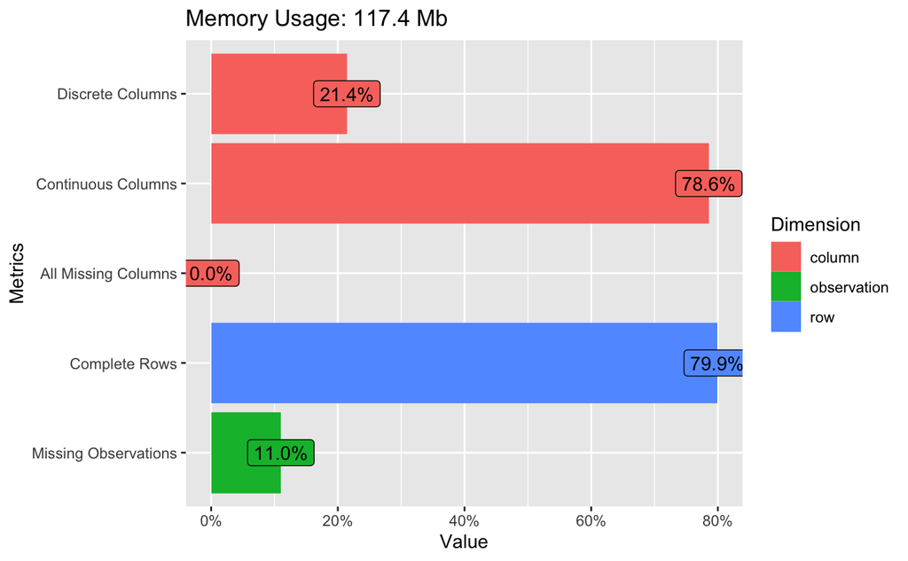

```r
plot_intro(games_details)
```

#### Missing values

Check for missing values using the function `plot_missing`. We see that there isn’t a variable with such missing values that needs to be removed. In that case we should use the `drop_columns` function.

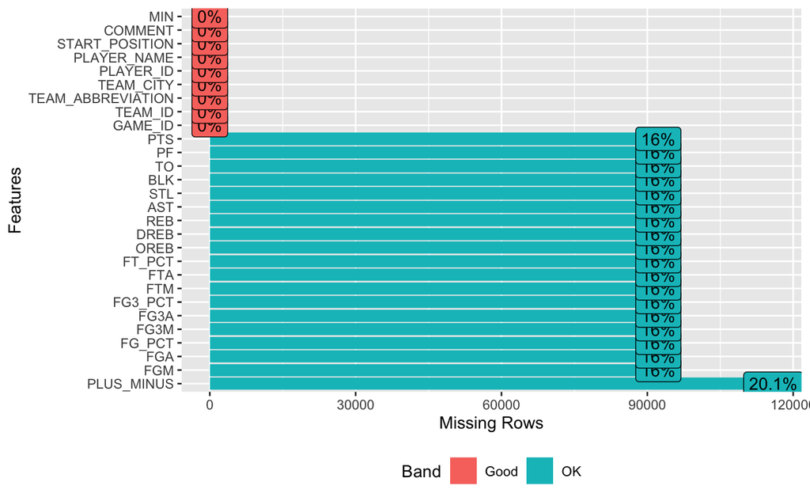

```r
plot_missing(games_details)
```

#### Bar charts

To visualize frequency distributions for all discrete features using the `plot_bar` function.

```
3 columns ignored with more than 50 categories.
PLAYER_NAME: 2294 categories
COMMENT: 5330 categories
MIN: 3383 categories
```

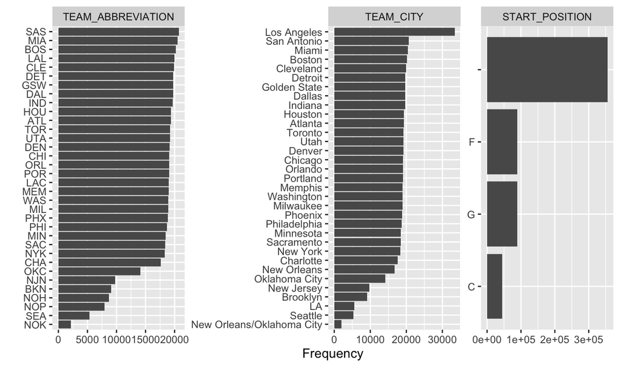

```r
plot_bar(games_details)
```

#### Histograms

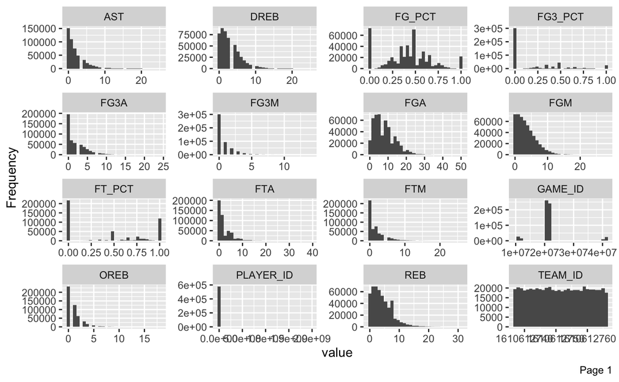

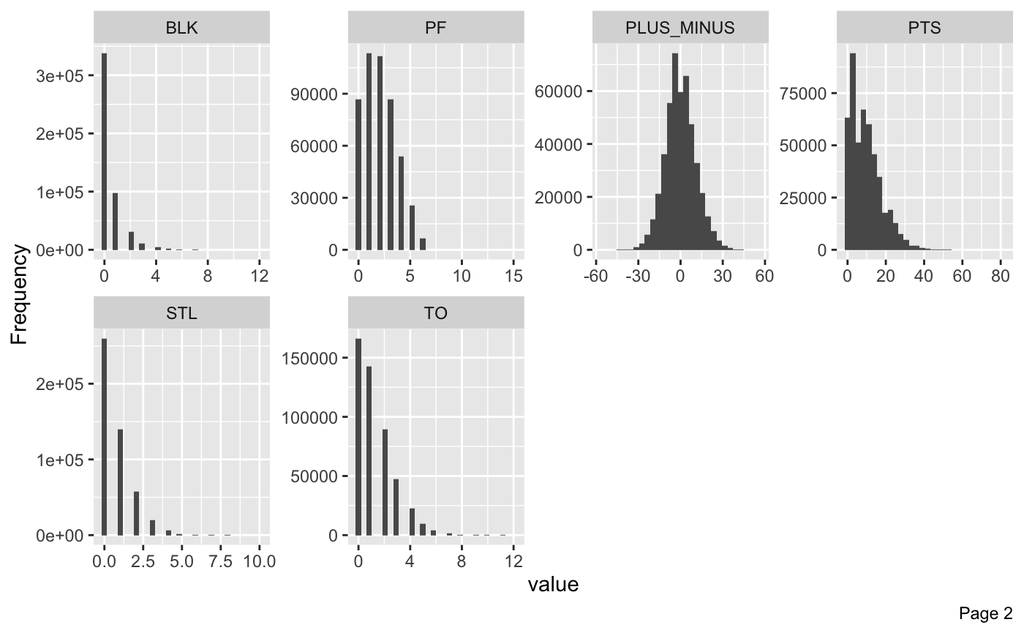

```r
plot_histogram(games_details)
```